# Hypothesis testing with general linear models and mixed models

Greg Maurer, Darren James

2022-06-19

## Introduction

(@Greg @Darren - this is the old outline for the workshop, we can update this or have this on the workshop page

We will cover:

- P values
- Common pitfalls
- Making inferences
- Understanding approximations underlying the analysis approach
- Rencher & Schaalje P-value interpretations
- Information-theoretic approaches

### Our data and R packages

You will need to have the `car` package installed, which adds additional options and specifications to fitted regression models, such as type-II and -III ANOVA output tables. You will also need `emmeans` to do post-hoc comparisons of groups in fitted linear models, and `lme4` to fit some mixed models.

Data for the exercises here come from the Jornada annual NPP data package on EDI. You can learn more about this dataset on the teaching datasets page. To load the data we will first load the `tidyverse` and use its `read_csv()` function to read in the data from EDI. Then we’ll look at the structure of this data.

```r
# Get tidyverse & the NPP data
library(tidyverse)

anpp <- read_csv('https://pasta.lternet.edu/package/data/eml/knb-lter-jrn/210011003/105/127124b0f04a1c71f34148e3d40a5c72')

str(anpp)
```

```
## spec_tbl_df [465 × 4] (S3: spec_tbl_df/tbl_df/tbl/data.frame)
##  $ year    : num [1:465] 1990 1990 1990 1990 1990 1990 1990 1990 1990 1990 ...
##  $ zone    : chr [1:465] "C" "C" "C" "G" ...
##  $ site    : chr [1:465] "CALI" "GRAV" "SAND" "BASN" ...
##  $ npp_g_m2: num [1:465] 28.6 85.7 103.3 77.2 34.1 ...
##  - attr(*, "spec")=
##   .. cols(
##   ..   year = col_double(),
##   ..   zone = col_character(),
##   ..   site = col_character(),
##   ..   npp_g_m2 = col_double()
##   .. )
##  - attr(*, "problems")=<externalptr>
```

We have four columns: `year` is a number representing the year of observation, `zone` is a character representing one of the 5 major vegetation zones at the Jornada, `site` is a string representing one of the 15 NPP study sites at the Jornada, and `npp_g_m2` is our observed NPP value in $g\cdot m^{-2}$.

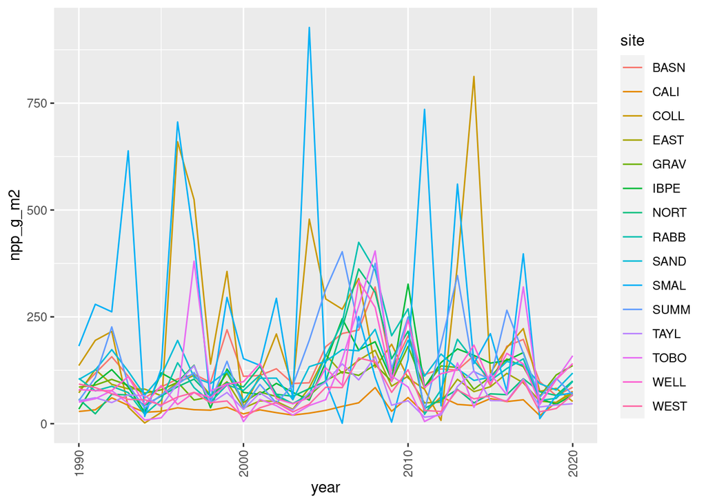

```r
# Then, make a summary figure
ggplot(anpp, aes(x = year, y = npp_g_m2, col = site, group = site)) +
  geom_line() +
  theme(axis.text.x = element_text(angle = 90, vjust = 0.5))
```

## Comparing two samples

We commonly need to compare two samples from a set of observations. In this lesson, we examine net primary production data (NPP) collected at the Jornada. This dataset has been collected for over 3 decades, and as shown above, there is significant variability from year to year. Lets begin by comparing observations in two years only, 2019 and 2020, to see if they are markedly different using a t-test.

First, create a dataframe that is subset of our full `anpp` dataframe.

```r
# Create a 2-year data subset
anpp.sub1 <- anpp %>%
  dplyr::filter(year %in% 2019:2020)
```

In t-tests we are usually testing whether the mean of two groups is different. Lets look at some summary statistics from our two years of data first.

```r
# Summary statistics
anpp.sub1.stats <- anpp.sub1 %>%
  group_by(year) %>%
  summarise(n = n(),
            mean = mean(npp_g_m2),
            std.dev = sd(npp_g_m2)) %>%
  mutate(std.err = std.dev/sqrt(n))

anpp.sub1.stats
```

```
## # A tibble: 2 × 5
##    year     n  mean std.dev std.err
##   <dbl> <int> <dbl>   <dbl>   <dbl>
## 1  2019    15  71.3    25.5    6.59
## 2  2020    15  90.6    34.0    8.78
```

From this we see that the means for each year are offset, increasing by about 19 $g\cdot m^{-2}$ from 2019 to 2020. There are also differences in the variance around the means, which we see as different standard deviation and error statistics.

For a t-test we first need to put data into “wide” form, with observations for the different years in separate columns.

```r
# Spread to wide form
anpp.sub1.wide <- anpp.sub1 %>%
  spread(year, npp_g_m2)

head(anpp.sub1.wide)
```

```
## # A tibble: 6 × 4
##   zone  site  `2019` `2020`
##   <chr> <chr>  <dbl>  <dbl>
## 1 C     CALI    49.7   75.7
## 2 C     GRAV   114.   136
## 3 C     SAND    78.8  118.
## 4 G     BASN    65.6   85.1
## 5 G     IBPE    45.5   67
## 6 G     SUMM   106.    67.4
```

Now do a t-test for differences in mean NPP in 2019 and 2020, using the `t.test()` function.

```r
# A default 2-sample t-test in R
t.test(x = anpp.sub1.wide$`2019`,
       y = anpp.sub1.wide$`2020`)
```

```
##
##  Welch Two Sample t-test
##
## data:  anpp.sub1.wide$`2019` and anpp.sub1.wide$`2020`
## t = -1.758, df = 25.98, p-value = 0.09053
## alternative hypothesis: true difference in means is not equal to 0
## 95 percent confidence interval:
##  -41.853213   3.266547
## sample estimates:
## mean of x mean of y
##  71.28000  90.57333
```

We see that the default here is a “Welch Two Sample t-test”, which is an unequal variance test. That means that the test is designed to account for differences in variance between the 2019 and 2020 sample. We’ll see later that testing two samples with different variances is something we could also do with a mixed model. This test tells us that there isn’t a “significant” difference in the means since the p-value is greater than 0.05, which is our $\alpha$ value, or the threshold we use to reject the null hypothesis that the two means are the same.

Lets look at some variations on the t-test. First, a standard Student’s t-test with equal, or pooled, variance.

```r
# t-test with equal variance
t.test(x = anpp.sub1.wide$`2019`,
       y = anpp.sub1.wide$`2020`,
       var.equal = TRUE)
```

```
##
##  Two Sample t-test
##
## data:  anpp.sub1.wide$`2019` and anpp.sub1.wide$`2020`
## t = -1.758, df = 28, p-value = 0.08968
## alternative hypothesis: true difference in means is not equal to 0
## 95 percent confidence interval:
##  -41.774212   3.187545
## sample estimates:
## mean of x mean of y
##  71.28000  90.57333
```

This lowers the p-value a tad, but is that a good thing? We’ve pooled the variance for 2019 and 2020, even though we saw from our summary statistics that the variances might be unequal, i.e., the standard deviation of the 2020 observations are higher.

Next lets try a paired t-test, which assumes that the observations in each sample are not independent. We know this is the case since we’re measuring the same sites each year, and therefore comparing two samples of the same experimental or statistical units (sites). In a paired t-test, the question becomes whether the difference between the two samples, 2019 and 2020 observations, is itself different than zero. Therefore, if we already know that we have unequal variances in our samples, taking the difference is a quick way to get around that issue.

```r
# Paired t-test
t.test(x = anpp.sub1.wide$`2019`,
       y = anpp.sub1.wide$`2020`,
       paired = TRUE)
```

```
##
##  Paired t-test
##
## data:  anpp.sub1.wide$`2019` and anpp.sub1.wide$`2020`
## t = -2.9119, df = 14, p-value = 0.01137
## alternative hypothesis: true mean difference is not equal to 0
## 95 percent confidence interval:
##  -33.50415  -5.08252
## sample estimates:
## mean difference
##       -19.29333
```

We have a significant result here (p-value < 0.05) which tells us that we can reject the null hypothesis that the difference between these two years of data is equal to zero. So, NPP changed from 2019 to 2020.

We’ll see later that this paired t-test can also be formulated as a mixed model.

## Interlude - how should we interpret p-values?

An opinionated section on hypothesis testing with p-values.

## Testing for unequal variance

Lets take a slightly larger slice of our original dataset now and examine changes in variance within it. We can create a new dataset with years 2017 to 2020.

```r
# Create a 4-year data subset
anpp.sub2 <- anpp %>%
  dplyr::filter(year %in% 2017:2020)
```

How would we test whether there are unequal variances within the samples we are comparing? If we plot the data, we will see some visual cues. Boxplots are a nice method for this.

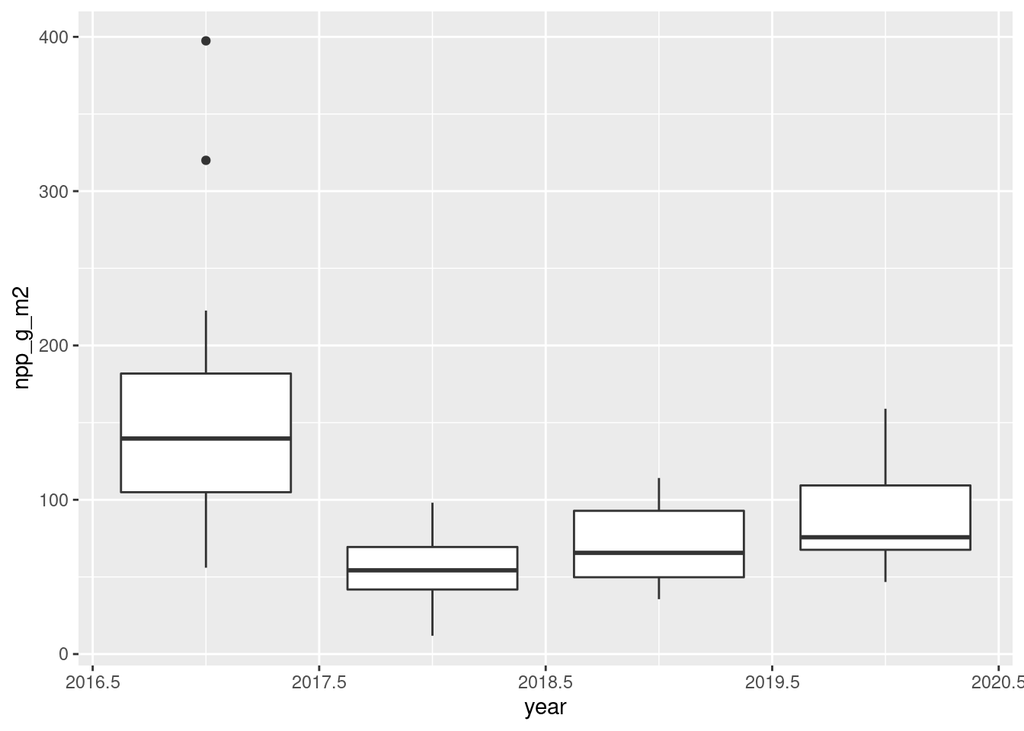

```r
ggplot(anpp.sub2, aes(x = year, y = npp_g_m2, group = year)) +
  geom_boxplot()
```

With the two additional years, we can see that some years, namely 2017, have much higher variance than others. We can use some additional tests to quantify that range in variance. (@Darren - I’m not sure what to say on these, and also not sure why we need the car package)

To give us some access to tests we’ll use, lets first load the `car` package.

```r
library(car)
```

```r
bartlett.test(npp_g_m2 ~ year, data = anpp.sub2)
```

```
##
##  Bartlett test of homogeneity of variances
##
## data:  npp_g_m2 by year
## Bartlett's K-squared = 34.515, df = 3, p-value = 1.542e-07
```

```r
fligner.test(npp_g_m2 ~ year, data = anpp.sub2)
```

```
##
##  Fligner-Killeen test of homogeneity of variances
##
## data:  npp_g_m2 by year
## Fligner-Killeen:med chi-squared = 7.2901, df = 3, p-value = 0.0632
```

```r
leveneTest(npp_g_m2 ~ as.factor(year), data = anpp.sub2) # from car package
```

```
## Levene's Test for Homogeneity of Variance (center = median)
##       Df F value  Pr(>F)
## group  3  3.4687 0.02201 *
##       56
## ---
## Signif. codes:  0 '***' 0.001 '**' 0.01 '*' 0.05 '.' 0.1 ' ' 1
```

## Comparing samples with general linear models

Comparing the mean of different samples, as we have done with t-tests, is also possible using *General linear models*, a class of procedures often used in standard statistics, including linear regression, one- and two-way analysis of variance (ANOVA), and analysis of covariance (ANCOVA). All of these are variations of “straight-line-fitting” statistics, and `R` uses the `lm()` function for all these procedures. Instead of comparing sample means directly, we are essentially comparing best-fit lines drawn between the mean values of the samples.

Lets go back to our 2019 and 2020 dataframe and compare the general linear models to the t-tests we did earlier in the lesson. A mean comparison test can be done as a linear regression, using `lm` directly. We will fit a model and then ask for summary results.

```r
# Two-sample mean comparison using a linear regression model
lm.ttest <- lm(npp_g_m2 ~ year, data = anpp.sub1)
summary(lm.ttest)
```

```
##
## Call:
## lm(formula = npp_g_m2 ~ year, data = anpp.sub1)
##
## Residuals:
##    Min     1Q Median     3Q    Max
## -43.87 -22.48  -5.73  23.80  68.43
##
## Coefficients:
##              Estimate Std. Error t value Pr(>|t|)
## (Intercept) -38881.96   22163.63  -1.754   0.0903 .
## year            19.29      10.97   1.758   0.0897 .
## ---
## Signif. codes:  0 '***' 0.001 '**' 0.01 '*' 0.05 '.' 0.1 ' ' 1
##
## Residual standard error: 30.06 on 28 degrees of freedom
## Multiple R-squared:  0.0994, Adjusted R-squared:  0.06724
## F-statistic:  3.09 on 1 and 28 DF,  p-value: 0.08968
```

We get quite a few details on the linear model fit here, and see that we have estimated the same difference in means and the same p-value as we had in the earlier equal-variance two-sample t-test.

If we want to look at how this model is being fit visually, we can make a plot using `ggplot`, which allows us to fitted models to a plot with `geom_smooth`. We need to specify the type of model as “lm” to get a linear model.

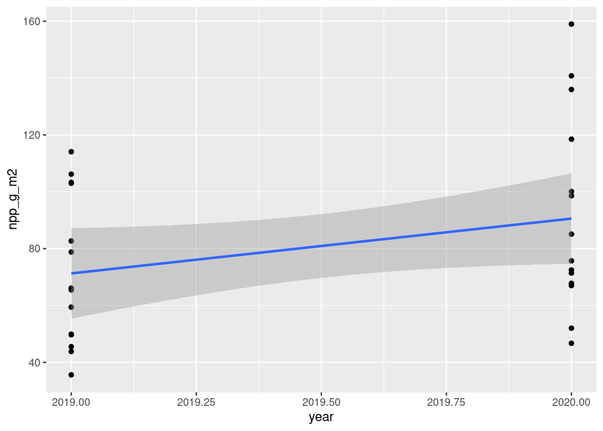

```r
ggplot(data=anpp.sub1, aes(x=year, y=npp_g_m2)) +
  geom_point() +
  geom_smooth(method="lm")
```

Notice the difference in the means, represented by the slope of the line, and the difference in the variance (vertical range of the points) between the 2019 and 2020 samples.

We can also compare the means using one-way ANOVA. The function to do this is `aov()`, but under the hood this is really just fitting an `lm` model again, which we can see by looking at the function documentation.

```r
?aov
```

One nuance here is that when given numerical predictor variables, like `year`, `lm` interprets these as a continuous variable. For ANOVA, we aim to analyze differences between discrete categories, so we should make sure we are using a `factor`, which is how `R` represents categorical variables. Lets convert `year` to a factor first.

```r
anpp.sub1.f <- anpp.sub1
anpp.sub1.f$year <- factor(anpp.sub1.f$year)
```

Now we can fit the ANOVA model using `aov()`, first specifying the linear model and dataframe to use, and then ask R for summary statistics.

```r
# One-way ANOVA equivalent to the 2-sample t-test
aov.ttest <- aov(npp_g_m2 ~ year, data = anpp.sub1.f)
summary(aov.ttest)
```

```
##             Df Sum Sq Mean Sq F value Pr(>F)
## year         1   2792  2791.7    3.09 0.0897 .
## Residuals   28  25294   903.3
## ---
## Signif. codes:  0 '***' 0.001 '**' 0.01 '*' 0.05 '.' 0.1 ' ' 1
```

```r
car::Anova(lm.ttest, type = "III") # Not clear on difference in outputs, p value is same.
```

```
## Anova Table (Type III tests)
##
## Response: npp_g_m2
##              Sum Sq Df F value  Pr(>F)
## (Intercept)  2780.2  1  3.0776 0.09032 .
## year         2791.7  1  3.0904 0.08968 .
## Residuals   25293.8 28
## ---
## Signif. codes:  0 '***' 0.001 '**' 0.01 '*' 0.05 '.' 0.1 ' ' 1
```

Notice that here, and when we used `lm`, our hypothesis test results were the same as with the unpaired, equal-variance, two sample t-test that we tried earlier. This suggests that by default, `lm` is making some assumptions that our observations are independent. We already know that they aren’t. Later, we’ll see some ways to account for this.

When we have multiple categories in our data, we can do a multi-way ANOVA by adding additional factors to the model. In our case we have aother categorical variable, called `zone`, that assigns each NPP site to one of the five major vegetation zones at Jornada. Since this is a character column `lm`, or `aov`, will interpret that column as a factor, and we don’t need to convert it first.

```r
# Two-way ANOVA using year and vegetation zone
aov.2way <- aov(npp_g_m2 ~ year + zone, data = anpp.sub1.f)
summary(aov.2way)
```

```
##             Df Sum Sq Mean Sq F value Pr(>F)
## year         1   2792  2791.7   3.884 0.0604 .
## zone         4   8042  2010.5   2.797 0.0488 *
## Residuals   24  17252   718.8
## ---
## Signif. codes:  0 '***' 0.001 '**' 0.01 '*' 0.05 '.' 0.1 ' ' 1
```

In our two-way ANOVA, we see that vegetation zone has a p-value below 0.05, which suggests that we might be able to reject the null hypothesis that all the vegetation zones have the same mean NPP value in 2019 and 2020.

This is all instructive, but we know that we should be using a paired model since our observations are not independent. In ANOVA, the term for this is *repeated measures*. To use repeated measures with `aov` we must add an “Error” term to our model that partitions the observed variance between years according to `site`, since `site` is our experimental unit or subject.

```r
# One-way, repeated measures ANOVA using year and site
aov.1way.rm <- aov(npp_g_m2 ~ year + Error(site/year),
                   data = anpp.sub1.f)
summary(aov.1way.rm)
```

```
##
## Error: site
##           Df Sum Sq Mean Sq F value Pr(>F)
## Residuals 14  20684    1477
##
## Error: site:year
##           Df Sum Sq Mean Sq F value Pr(>F)
## year       1   2792  2791.7   8.479 0.0114 *
## Residuals 14   4610   329.3
## ---
## Signif. codes:  0 '***' 0.001 '**' 0.01 '*' 0.05 '.' 0.1 ' ' 1
```

Somewhat unsurprisingly here, we have gotten the same result as with the earlier paired t-test. This also suggests that we can use linear models to partition variance according to the groups in our data. Why would we want to do that?

(@Greg @Darren - this seems like a good place to jump to mixed models, but do we need a better explanation here first…?).

## Interlude - Unequal variance and random effects

## Into the wilderness with linear mixed models